# Geo-Visual Analytics: Site Selection for Starbucks

*Based on Giulia Carella's Notebook presented in:*

SDSC20 Workshop - Integrating CARTOframes into Spatial Data Science workflows. October 21 2020

# Practice goals:

In this practice we will be a Spatial Data Science in a geo-planning department. We will lead a project for site selection to our company, **Starbucks**. Site selections refers to the process of deciding where to open a new or relocate an exiting store/facility by comparing the merits of potential locations. In previous practices, we learnt the concept of **potential** as the total amount of expense/revenues that an entity (e.g. a company, shop, etc...) can generate. If some attribute of interest is known (e.g. the revenues of existing stores) statistical and machine learning methods can be used to help with the decision process.

In this practice, we will support our company to look at where Starbucks should open new coffee shops in Long Island, NY. Specifically, we will build a model for the revenues of the existing stores as a funcion of sociodemographic data and use this model to predict the expected revenue in each block group.

We will:

- Read and upload to CARTO the revenue data
- Geocode the store adresses (i.e. convert addresses to coordinates)
- Download for Long Island the US Census data by block group
- Enrich each store location with the corresponding block group level Census data
- Build a predictive model for the store revenues
- Publish a visualization with the results

# 0. Context: Site Selection

## 0.1 Set up the environment

First of all, install virtualenv inside your project folder to secure your project directory to avoid conflict with your other packages.

*pip install virtualenv*

After installing this run this command one by one inside your root project directory:

*virtualenv venv*

*source venv/bin/activate*

Now Your directory is secure and you can install your required packages inside.

*pip install -r requirements.txt*

(In case of error when installing Rtree package, please, use the following instruction in your directory: pip install "rtree>=0.8,<0.9"

To exit the virtual environment type:

*deactivate*

## 0.2 Imports

```python
from requirements import *
from ppca import PPCA
from utils import *
```

## 0.3 Set CARTO credentials

Access to you Carto account (www.Carto.com) and access to your CARTO dashboard (with **your login and password**) and click on **API KEY** to get your key.

```python
carto_username = '*'
carto_API = '*'

set_default_credentials(username=carto_username, api_key=carto_API)
```

## 0.4. Dataset: Upload Starbucks store data to your CARTO account

First we upload the Starbucks data that are stored in your local in the starbucks_long_island.csv file. The data contains the addresses of Starbucks stores, their annual revenue ($) and some store characteristics (e.g. the number of open hours per week).

```python
stores = pd.read_csv('./data/starbucks_long_island.csv')
stores.head(3)
```

|  | name | addresslines | hours_open_per_week | gc_status_rel | has_lu | has_cl | has_wa | has_vs | zipcode | storenumber | revenue |
| --- | --- | --- | --- | --- | --- | --- | --- | --- | --- | --- | --- |
| 0 | 7000 Austin Street | 7000 Austin Street,Forest Hills, NY 11375 | 108.0 | 0.97 | 1 | 1 | 1 | 1 | 11375 | 7217-623 | 1.016898e+06 |
| 1 | 107-12 Continental Avenue | 107-12 Continental Avenue,Forest Hills, NY 11375 | 116.5 | 0.95 | 1 | 0 | 1 | 0 | 11375 | 7349-910 | 4.470646e+05 |
| 2 | Stop & Shop-Forest Hills #539 | 8989 Union Turnpike,Forest Hills, NY 11375 | 112.0 | 0.97 | 0 | 0 | 1 | 0 | 11375 | 73708-104729 | 7.028071e+05 |

# 1. Data understanding

**[EX 1]** Explore the dataset to identify the number of registers or samples, variables, nulls and type of variables

```python
stores.info(memory_usage=False)
print('\n' * 2)
print('The dataset has 177 entries with 11 different features each.')
print('All the variables are null-free.')
print('All the variables except: Name, Addresslines and StoreNumber are recognised as numbers (either int or float.)')
```

```
<class 'pandas.core.frame.DataFrame'>
RangeIndex: 177 entries, 0 to 176
Data columns (total 11 columns):
 #   Column               Non-Null Count  Dtype
---  ------               --------------  -----
 0   name                 177 non-null    object
 1   addresslines         177 non-null    object
 2   hours_open_per_week  177 non-null    float64
 3   gc_status_rel        177 non-null    float64
 4   has_lu               177 non-null    int64
 5   has_cl               177 non-null    int64
 6   has_wa               177 non-null    int64
 7   has_vs               177 non-null    int64
 8   zipcode              177 non-null    int64
 9   storenumber          177 non-null    object
 10  revenue              177 non-null    float64
dtypes: float64(3), int64(5), object(3)


The dataset has 177 entries with 11 different features each.
All the variables are null-free.
All the variables except: Name, Addresslines and StoreNumber are recognised as numbers (either int or float.)
```

**[EX 2]** Plot the distribution and the boxplot of the annual revenues by store

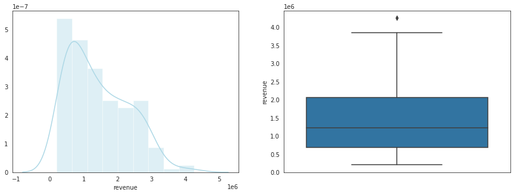

```python
fig = plt.figure(figsize=(5, 5))

fig,axes=plt.subplots(1,2, figsize=(15, 5))
sns.distplot(stores['revenue'], color="lightblue", ax=axes[0])
sns.boxplot(data=stores, y= 'revenue', orient='v', ax=axes[1])
plt.show()
```

**[EX 3]** Which other exploratory analysis do you propose to have a clear understanding of the data?

```python
list_binary_varibables = []
for col in stores.columns:
    if len(stores[col].unique()) == 2:
        list_binary_varibables.append(col)

list_binary_varibables
```

```
['has_lu', 'has_cl', 'has_wa', 'has_vs']
```

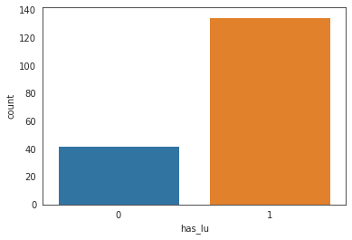

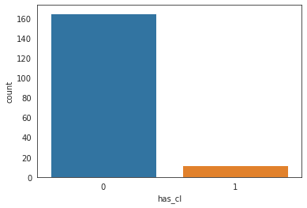

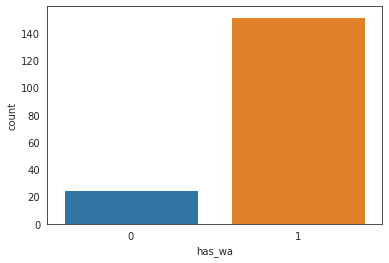

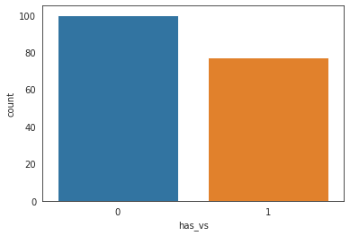

```python
#for variables with only two values, we plot countplots
for var in list_binary_varibables:
    ax = sns.countplot(x=var, data=stores)
    plt.show()
```

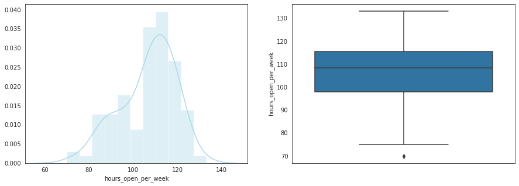

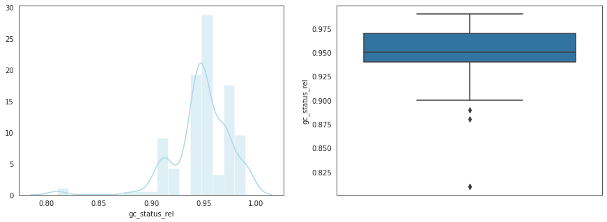

```python
#for the other numerical variables, we plot a histogram and a boxplot

for var in ['hours_open_per_week', 'gc_status_rel']:
    fig = plt.figure(figsize=(5, 5))

    fig,axes=plt.subplots(1,2, figsize=(15, 5))
    sns.distplot(stores[var], color="lightblue", ax=axes[0])
    sns.boxplot(data=stores, y= var, orient='v', ax=axes[1])
    plt.show()
```